# Risk Factor Analysis

## Outcome Variable

**Outcome Variable:** stunted

## Predictor Variables

**Intervention Variable:** predfeed36

**Adjustment Set:**

- arm
- sex
- month
- brthmon
- W_mage
- meducyrs
- feducyrs
- hhwealth_quart
- hfoodsec
- W_mhtcm
- vagbrth
- W_gagebrth
- W_birthwt
- W_birthlen
- W_nrooms
- W_nchldlt5
- W_parity
- impfloor
- impsan
- safeh20
- delta_W_mage
- delta_meducyrs
- delta_feducyrs
- delta_hhwealth_quart
- delta_hfoodsec
- delta_W_mhtcm
- delta_vagbrth
- delta_W_gagebrth
- delta_W_birthwt
- delta_W_birthlen
- delta_W_nrooms
- delta_W_nchldlt5
- delta_W_parity
- delta_impfloor
- delta_impsan
- delta_safeh20

## Stratifying Variables

The analysis was stratified on these variable(s):

- agecat
- studyid
- country

## Data Summary

| agecat | studyid | country | predfeed36 | stunted | n_cell | n |
| --- | --- | --- | --- | --- | --- | --- |
| Birth | ki0047075b-MAL-ED | BANGLADESH | 1 | 0 | 107 | 243 |
| Birth | ki0047075b-MAL-ED | BANGLADESH | 1 | 1 | 18 | 243 |
| Birth | ki0047075b-MAL-ED | BANGLADESH | 0 | 0 | 95 | 243 |
| Birth | ki0047075b-MAL-ED | BANGLADESH | 0 | 1 | 23 | 243 |
| Birth | ki0047075b-MAL-ED | BRAZIL | 1 | 0 | 25 | 185 |
| Birth | ki0047075b-MAL-ED | BRAZIL | 1 | 1 | 4 | 185 |
| Birth | ki0047075b-MAL-ED | BRAZIL | 0 | 0 | 141 | 185 |
| Birth | ki0047075b-MAL-ED | BRAZIL | 0 | 1 | 15 | 185 |
| Birth | ki0047075b-MAL-ED | INDIA | 1 | 0 | 11 | 198 |
| Birth | ki0047075b-MAL-ED | INDIA | 1 | 1 | 5 | 198 |
| Birth | ki0047075b-MAL-ED | INDIA | 0 | 0 | 155 | 198 |
| Birth | ki0047075b-MAL-ED | INDIA | 0 | 1 | 27 | 198 |
| Birth | ki0047075b-MAL-ED | NEPAL | 1 | 0 | 24 | 172 |
| Birth | ki0047075b-MAL-ED | NEPAL | 1 | 1 | 2 | 172 |
| Birth | ki0047075b-MAL-ED | NEPAL | 0 | 0 | 130 | 172 |
| Birth | ki0047075b-MAL-ED | NEPAL | 0 | 1 | 16 | 172 |
| Birth | ki0047075b-MAL-ED | PERU | 1 | 0 | 106 | 273 |
| Birth | ki0047075b-MAL-ED | PERU | 1 | 1 | 12 | 273 |
| Birth | ki0047075b-MAL-ED | PERU | 0 | 0 | 135 | 273 |
| Birth | ki0047075b-MAL-ED | PERU | 0 | 1 | 20 | 273 |
| Birth | ki0047075b-MAL-ED | SOUTH AFRICA | 1 | 0 | 1 | 236 |
| Birth | ki0047075b-MAL-ED | SOUTH AFRICA | 1 | 1 | 2 | 236 |
| Birth | ki0047075b-MAL-ED | SOUTH AFRICA | 0 | 0 | 211 | 236 |
| Birth | ki0047075b-MAL-ED | SOUTH AFRICA | 0 | 1 | 22 | 236 |
| Birth | ki0047075b-MAL-ED | TANZANIA, UNITED REPUBLIC OF | 1 | 0 | 1 | 121 |
| Birth | ki0047075b-MAL-ED | TANZANIA, UNITED REPUBLIC OF | 1 | 1 | 0 | 121 |
| Birth | ki0047075b-MAL-ED | TANZANIA, UNITED REPUBLIC OF | 0 | 0 | 102 | 121 |
| Birth | ki0047075b-MAL-ED | TANZANIA, UNITED REPUBLIC OF | 0 | 1 | 18 | 121 |
| Birth | ki1000109-EE | PAKISTAN | 1 | 0 | 1 | 2 |
| Birth | ki1000109-EE | PAKISTAN | 1 | 1 | 0 | 2 |

[output cut: 106 more lines]

The following strata were considered:

- agecat: 24 months, studyid: ki0047075b-MAL-ED, country: BANGLADESH
- agecat: 24 months, studyid: ki0047075b-MAL-ED, country: BRAZIL
- agecat: 24 months, studyid: ki0047075b-MAL-ED, country: INDIA
- agecat: 24 months, studyid: ki0047075b-MAL-ED, country: NEPAL
- agecat: 24 months, studyid: ki0047075b-MAL-ED, country: PERU
- agecat: 24 months, studyid: ki0047075b-MAL-ED, country: SOUTH AFRICA
- agecat: 24 months, studyid: ki0047075b-MAL-ED, country: TANZANIA, UNITED REPUBLIC OF
- agecat: 24 months, studyid: ki1113344-GMS-Nepal, country: NEPAL
- agecat: 24 months, studyid: ki1148112-LCNI-5, country: MALAWI
- agecat: 24 months, studyid: kiGH5241-JiVitA-3, country: BANGLADESH
- agecat: 24 months, studyid: kiGH5241-JiVitA-4, country: BANGLADESH
- agecat: 6 months, studyid: ki0047075b-MAL-ED, country: BANGLADESH
- agecat: 6 months, studyid: ki0047075b-MAL-ED, country: BRAZIL
- agecat: 6 months, studyid: ki0047075b-MAL-ED, country: INDIA
- agecat: 6 months, studyid: ki0047075b-MAL-ED, country: NEPAL
- agecat: 6 months, studyid: ki0047075b-MAL-ED, country: PERU
- agecat: 6 months, studyid: ki0047075b-MAL-ED, country: SOUTH AFRICA
- agecat: 6 months, studyid: ki0047075b-MAL-ED, country: TANZANIA, UNITED REPUBLIC OF
- agecat: 6 months, studyid: ki1000109-EE, country: PAKISTAN
- agecat: 6 months, studyid: ki1000304b-SAS-FoodSuppl, country: INDIA
- agecat: 6 months, studyid: ki1113344-GMS-Nepal, country: NEPAL
- agecat: 6 months, studyid: ki1148112-LCNI-5, country: MALAWI
- agecat: 6 months, studyid: kiGH5241-JiVitA-3, country: BANGLADESH
- agecat: 6 months, studyid: kiGH5241-JiVitA-4, country: BANGLADESH
- agecat: Birth, studyid: ki0047075b-MAL-ED, country: BANGLADESH
- agecat: Birth, studyid: ki0047075b-MAL-ED, country: BRAZIL
- agecat: Birth, studyid: ki0047075b-MAL-ED, country: INDIA
- agecat: Birth, studyid: ki0047075b-MAL-ED, country: NEPAL
- agecat: Birth, studyid: ki0047075b-MAL-ED, country: PERU
- agecat: Birth, studyid: ki0047075b-MAL-ED, country: SOUTH AFRICA
- agecat: Birth, studyid: ki0047075b-MAL-ED, country: TANZANIA, UNITED REPUBLIC OF
- agecat: Birth, studyid: ki1000109-EE, country: PAKISTAN
- agecat: Birth, studyid: kiGH5241-JiVitA-3, country: BANGLADESH
- agecat: Birth, studyid: kiGH5241-JiVitA-4, country: BANGLADESH

### Dropped Strata

Some strata were dropped due to rare outcomes:

- agecat: Birth, studyid: ki0047075b-MAL-ED, country: BRAZIL
- agecat: Birth, studyid: ki0047075b-MAL-ED, country: NEPAL
- agecat: Birth, studyid: ki0047075b-MAL-ED, country: SOUTH AFRICA
- agecat: Birth, studyid: ki0047075b-MAL-ED, country: TANZANIA, UNITED REPUBLIC OF
- agecat: Birth, studyid: ki1000109-EE, country: PAKISTAN
- agecat: 6 months, studyid: ki0047075b-MAL-ED, country: BRAZIL
- agecat: 6 months, studyid: ki0047075b-MAL-ED, country: NEPAL
- agecat: 6 months, studyid: ki0047075b-MAL-ED, country: SOUTH AFRICA
- agecat: 6 months, studyid: ki0047075b-MAL-ED, country: TANZANIA, UNITED REPUBLIC OF
- agecat: 6 months, studyid: ki1000304b-SAS-FoodSuppl, country: INDIA
- agecat: 24 months, studyid: ki0047075b-MAL-ED, country: BRAZIL
- agecat: 24 months, studyid: ki0047075b-MAL-ED, country: SOUTH AFRICA
- agecat: 24 months, studyid: ki0047075b-MAL-ED, country: TANZANIA, UNITED REPUBLIC OF

## Methods Detail

We’re interested in the causal parameters $E[Y_a]$ for all values of $a \in \mathcal{A}$. These parameters represent the mean outcome if, possibly contrary to fact, we intervened to set all units to have $A=a$. Under the randomization and positivity assumptions, these are identified by the statistical parameters $\psi_a=E_W[E_{Y|A,W}(Y|A=a,W)]$. In addition, we’re interested in the mean of $Y$, $E[Y]$ under no intervention (the observed mean). We will estimate these parameters by using SuperLearner to fit the relevant likelihood factors – $E_{Y|A,W}(Y|A=a,W)$ and $p(A=a|W)$, and then updating our likelihood fit using a joint TMLE.

For unadjusted analyses ($W=\{\}$), initial likelihoods were estimated using Lrnr_glm to estimate the simple $E(Y|A)$ and Lrnr_mean to estimate $p(A)$. For adjusted analyses, a small library containing Lrnr_glmnet, Lrnr_xgboost, and Lrnr_mean was used.

Having estimated these parameters, we will then use the delta method to estimate relative risks and attributable risks relative to a prespecified baseline level of $A$.

# Results Detail

## Results Plots

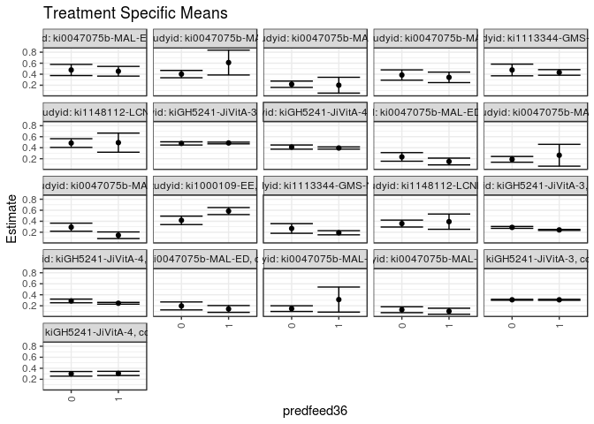

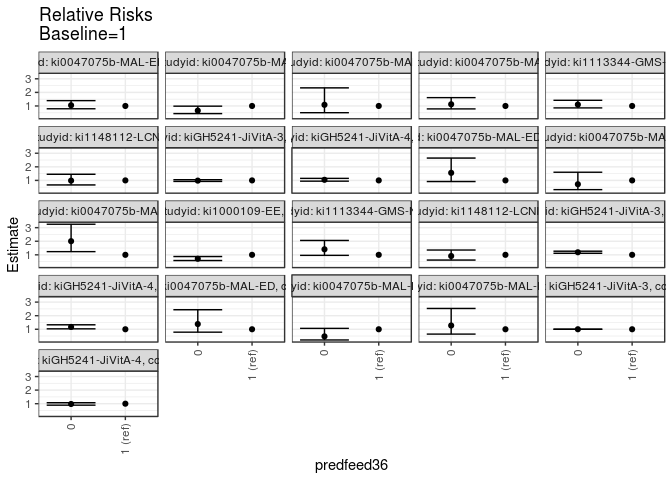

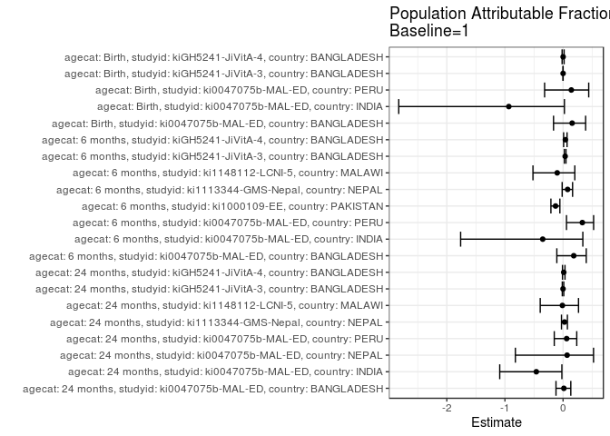

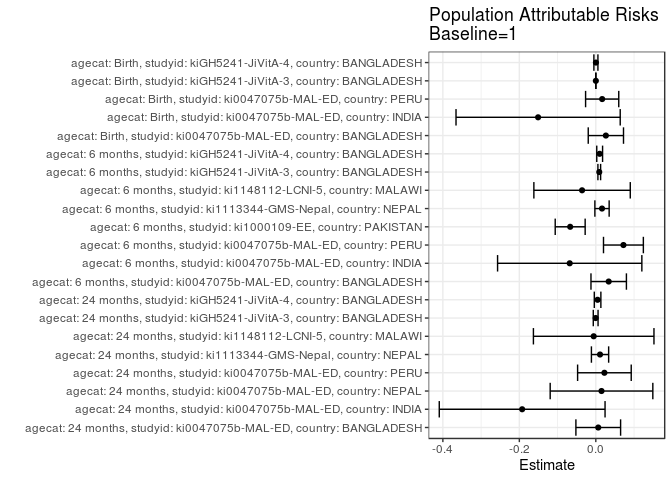

## Results Table

### Parameter: TSM

| agecat | studyid | country | intervention_level | baseline_level | estimate | ci_lower | ci_upper |
| --- | --- | --- | --- | --- | --- | --- | --- |
| Birth | ki0047075b-MAL-ED | BANGLADESH | 1 | NA | 0.1423905 | 0.0806163 | 0.2041647 |
| Birth | ki0047075b-MAL-ED | BANGLADESH | 0 | NA | 0.1969885 | 0.1249828 | 0.2689941 |
| Birth | ki0047075b-MAL-ED | INDIA | 1 | NA | 0.3125000 | 0.0848074 | 0.5401926 |
| Birth | ki0047075b-MAL-ED | INDIA | 0 | NA | 0.1483516 | 0.0965804 | 0.2001228 |
| Birth | ki0047075b-MAL-ED | PERU | 1 | NA | 0.1005687 | 0.0457287 | 0.1554088 |
| Birth | ki0047075b-MAL-ED | PERU | 0 | NA | 0.1283600 | 0.0752478 | 0.1814723 |
| Birth | kiGH5241-JiVitA-3 | BANGLADESH | 1 | NA | 0.3082958 | 0.2996233 | 0.3169682 |
| Birth | kiGH5241-JiVitA-3 | BANGLADESH | 0 | NA | 0.3087432 | 0.3000736 | 0.3174128 |
| Birth | kiGH5241-JiVitA-4 | BANGLADESH | 1 | NA | 0.3064730 | 0.2683747 | 0.3445712 |
| Birth | kiGH5241-JiVitA-4 | BANGLADESH | 0 | NA | 0.2995027 | 0.2572030 | 0.3418024 |
| 6 months | ki0047075b-MAL-ED | BANGLADESH | 1 | NA | 0.1496208 | 0.0882399 | 0.2110017 |
| 6 months | ki0047075b-MAL-ED | BANGLADESH | 0 | NA | 0.2328920 | 0.1550275 | 0.3107565 |
| 6 months | ki0047075b-MAL-ED | INDIA | 1 | NA | 0.2631579 | 0.0647364 | 0.4615794 |
| 6 months | ki0047075b-MAL-ED | INDIA | 0 | NA | 0.1889401 | 0.1367451 | 0.2411351 |
| 6 months | ki0047075b-MAL-ED | PERU | 1 | NA | 0.1454652 | 0.0852118 | 0.2057186 |
| 6 months | ki0047075b-MAL-ED | PERU | 0 | NA | 0.2916420 | 0.2181953 | 0.3650887 |
| 6 months | ki1000109-EE | PAKISTAN | 1 | NA | 0.5847156 | 0.5211869 | 0.6482444 |
| 6 months | ki1000109-EE | PAKISTAN | 0 | NA | 0.4162571 | 0.3395388 | 0.4929754 |
| 6 months | ki1113344-GMS-Nepal | NEPAL | 1 | NA | 0.1909902 | 0.1534433 | 0.2285372 |
| 6 months | ki1113344-GMS-Nepal | NEPAL | 0 | NA | 0.2686976 | 0.1813331 | 0.3560621 |
| 6 months | ki1148112-LCNI-5 | MALAWI | 1 | NA | 0.3925370 | 0.2540233 | 0.5310507 |
| 6 months | ki1148112-LCNI-5 | MALAWI | 0 | NA | 0.3578946 | 0.2950844 | 0.4207048 |
| 6 months | kiGH5241-JiVitA-3 | BANGLADESH | 1 | NA | 0.2423903 | 0.2332512 | 0.2515293 |
| 6 months | kiGH5241-JiVitA-3 | BANGLADESH | 0 | NA | 0.2882435 | 0.2710328 | 0.3054541 |
| 6 months | kiGH5241-JiVitA-4 | BANGLADESH | 1 | NA | 0.2457139 | 0.2296023 | 0.2618256 |
| 6 months | kiGH5241-JiVitA-4 | BANGLADESH | 0 | NA | 0.2876955 | 0.2542625 | 0.3211285 |
| 24 months | ki0047075b-MAL-ED | BANGLADESH | 1 | NA | 0.4533235 | 0.3652779 | 0.5413690 |
| 24 months | ki0047075b-MAL-ED | BANGLADESH | 0 | NA | 0.4765763 | 0.3752626 | 0.5778901 |
| 24 months | ki0047075b-MAL-ED | INDIA | 1 | NA | 0.6111111 | 0.3854050 | 0.8368173 |
| 24 months | ki0047075b-MAL-ED | INDIA | 0 | NA | 0.4019139 | 0.3352973 | 0.4685304 |
| 24 months | ki0047075b-MAL-ED | NEPAL | 1 | NA | 0.2000000 | 0.0565495 | 0.3434505 |
| 24 months | ki0047075b-MAL-ED | NEPAL | 0 | NA | 0.2171717 | 0.1596138 | 0.2747296 |
| 24 months | ki0047075b-MAL-ED | PERU | 1 | NA | 0.3424799 | 0.2471832 | 0.4377767 |
| 24 months | ki0047075b-MAL-ED | PERU | 0 | NA | 0.3850393 | 0.2916074 | 0.4784713 |
| 24 months | ki1113344-GMS-Nepal | NEPAL | 1 | NA | 0.4319348 | 0.3812848 | 0.4825848 |
| 24 months | ki1113344-GMS-Nepal | NEPAL | 0 | NA | 0.4767735 | 0.3707018 | 0.5828452 |
| 24 months | ki1148112-LCNI-5 | MALAWI | 1 | NA | 0.4923093 | 0.3188293 | 0.6657893 |
| 24 months | ki1148112-LCNI-5 | MALAWI | 0 | NA | 0.4844090 | 0.4053420 | 0.5634760 |
| 24 months | kiGH5241-JiVitA-3 | BANGLADESH | 1 | NA | 0.4860856 | 0.4706996 | 0.5014715 |
| 24 months | kiGH5241-JiVitA-3 | BANGLADESH | 0 | NA | 0.4781936 | 0.4491814 | 0.5072059 |
| 24 months | kiGH5241-JiVitA-4 | BANGLADESH | 1 | NA | 0.3945507 | 0.3743905 | 0.4147110 |
| 24 months | kiGH5241-JiVitA-4 | BANGLADESH | 0 | NA | 0.4114581 | 0.3733039 | 0.4496124 |

### Parameter: E(Y)

| agecat | studyid | country | intervention_level | baseline_level | estimate | ci_lower | ci_upper |
| --- | --- | --- | --- | --- | --- | --- | --- |
| Birth | ki0047075b-MAL-ED | BANGLADESH | NA | NA | 0.1687243 | 0.1215395 | 0.2159090 |
| Birth | ki0047075b-MAL-ED | INDIA | NA | NA | 0.1616162 | 0.1102143 | 0.2130180 |
| Birth | ki0047075b-MAL-ED | PERU | NA | NA | 0.1172161 | 0.0789879 | 0.1554444 |
| Birth | kiGH5241-JiVitA-3 | BANGLADESH | NA | NA | 0.3084038 | 0.2997331 | 0.3170746 |
| Birth | kiGH5241-JiVitA-4 | BANGLADESH | NA | NA | 0.3067400 | 0.2694794 | 0.3440006 |
| 6 months | ki0047075b-MAL-ED | BANGLADESH | NA | NA | 0.1833333 | 0.1342773 | 0.2323893 |
| 6 months | ki0047075b-MAL-ED | INDIA | NA | NA | 0.1949153 | 0.1442678 | 0.2455627 |
| 6 months | ki0047075b-MAL-ED | PERU | NA | NA | 0.2177122 | 0.1684866 | 0.2669378 |
| 6 months | ki1000109-EE | PAKISTAN | NA | NA | 0.5177112 | 0.4665188 | 0.5689035 |
| 6 months | ki1113344-GMS-Nepal | NEPAL | NA | NA | 0.2072243 | 0.1725535 | 0.2418951 |
| 6 months | ki1148112-LCNI-5 | MALAWI | NA | NA | 0.3566176 | 0.2995882 | 0.4136471 |
| 6 months | kiGH5241-JiVitA-3 | BANGLADESH | NA | NA | 0.2514393 | 0.2427410 | 0.2601375 |
| 6 months | kiGH5241-JiVitA-4 | BANGLADESH | NA | NA | 0.2558140 | 0.2405969 | 0.2710310 |
| 24 months | ki0047075b-MAL-ED | BANGLADESH | NA | NA | 0.4597156 | 0.3923103 | 0.5271210 |
| 24 months | ki0047075b-MAL-ED | INDIA | NA | NA | 0.4185022 | 0.3541865 | 0.4828179 |
| 24 months | ki0047075b-MAL-ED | NEPAL | NA | NA | 0.2149123 | 0.1614774 | 0.2683472 |
| 24 months | ki0047075b-MAL-ED | PERU | NA | NA | 0.3650000 | 0.2981110 | 0.4318890 |
| 24 months | ki1113344-GMS-Nepal | NEPAL | NA | NA | 0.4429825 | 0.3973399 | 0.4886250 |
| 24 months | ki1148112-LCNI-5 | MALAWI | NA | NA | 0.4867725 | 0.4153250 | 0.5582200 |
| 24 months | kiGH5241-JiVitA-3 | BANGLADESH | NA | NA | 0.4857314 | 0.4714029 | 0.5000599 |
| 24 months | kiGH5241-JiVitA-4 | BANGLADESH | NA | NA | 0.3992046 | 0.3802350 | 0.4181742 |

### Parameter: RR

| agecat | studyid | country | intervention_level | baseline_level | estimate | ci_lower | ci_upper |
| --- | --- | --- | --- | --- | --- | --- | --- |
| Birth | ki0047075b-MAL-ED | BANGLADESH | 1 | 1 | 1.0000000 | 1.0000000 | 1.0000000 |
| Birth | ki0047075b-MAL-ED | BANGLADESH | 0 | 1 | 1.3834384 | 0.7849405 | 2.4382761 |
| Birth | ki0047075b-MAL-ED | INDIA | 1 | 1 | 1.0000000 | 1.0000000 | 1.0000000 |
| Birth | ki0047075b-MAL-ED | INDIA | 0 | 1 | 0.4747253 | 0.2116341 | 1.0648762 |
| Birth | ki0047075b-MAL-ED | PERU | 1 | 1 | 1.0000000 | 1.0000000 | 1.0000000 |
| Birth | ki0047075b-MAL-ED | PERU | 0 | 1 | 1.2763414 | 0.6436377 | 2.5310006 |
| Birth | kiGH5241-JiVitA-3 | BANGLADESH | 1 | 1 | 1.0000000 | 1.0000000 | 1.0000000 |
| Birth | kiGH5241-JiVitA-3 | BANGLADESH | 0 | 1 | 1.0014513 | 1.0003127 | 1.0025911 |
| Birth | kiGH5241-JiVitA-4 | BANGLADESH | 1 | 1 | 1.0000000 | 1.0000000 | 1.0000000 |
| Birth | kiGH5241-JiVitA-4 | BANGLADESH | 0 | 1 | 0.9772564 | 0.8913663 | 1.0714227 |
| 6 months | ki0047075b-MAL-ED | BANGLADESH | 1 | 1 | 1.0000000 | 1.0000000 | 1.0000000 |
| 6 months | ki0047075b-MAL-ED | BANGLADESH | 0 | 1 | 1.5565487 | 0.9160027 | 2.6450182 |
| 6 months | ki0047075b-MAL-ED | INDIA | 1 | 1 | 1.0000000 | 1.0000000 | 1.0000000 |
| 6 months | ki0047075b-MAL-ED | INDIA | 0 | 1 | 0.7179724 | 0.3216345 | 1.6027022 |
| 6 months | ki0047075b-MAL-ED | PERU | 1 | 1 | 1.0000000 | 1.0000000 | 1.0000000 |
| 6 months | ki0047075b-MAL-ED | PERU | 0 | 1 | 2.0048922 | 1.2357622 | 3.2527237 |
| 6 months | ki1000109-EE | PAKISTAN | 1 | 1 | 1.0000000 | 1.0000000 | 1.0000000 |
| 6 months | ki1000109-EE | PAKISTAN | 0 | 1 | 0.7118966 | 0.5796844 | 0.8742633 |
| 6 months | ki1113344-GMS-Nepal | NEPAL | 1 | 1 | 1.0000000 | 1.0000000 | 1.0000000 |
| 6 months | ki1113344-GMS-Nepal | NEPAL | 0 | 1 | 1.4068657 | 0.9617359 | 2.0580194 |
| 6 months | ki1148112-LCNI-5 | MALAWI | 1 | 1 | 1.0000000 | 1.0000000 | 1.0000000 |
| 6 months | ki1148112-LCNI-5 | MALAWI | 0 | 1 | 0.9117474 | 0.6147849 | 1.3521530 |
| 6 months | kiGH5241-JiVitA-3 | BANGLADESH | 1 | 1 | 1.0000000 | 1.0000000 | 1.0000000 |
| 6 months | kiGH5241-JiVitA-3 | BANGLADESH | 0 | 1 | 1.1891709 | 1.1160146 | 1.2671227 |
| 6 months | kiGH5241-JiVitA-4 | BANGLADESH | 1 | 1 | 1.0000000 | 1.0000000 | 1.0000000 |
| 6 months | kiGH5241-JiVitA-4 | BANGLADESH | 0 | 1 | 1.1708554 | 1.0323534 | 1.3279391 |
| 24 months | ki0047075b-MAL-ED | BANGLADESH | 1 | 1 | 1.0000000 | 1.0000000 | 1.0000000 |
| 24 months | ki0047075b-MAL-ED | BANGLADESH | 0 | 1 | 1.0512942 | 0.7929401 | 1.3938248 |
| 24 months | ki0047075b-MAL-ED | INDIA | 1 | 1 | 1.0000000 | 1.0000000 | 1.0000000 |
| 24 months | ki0047075b-MAL-ED | INDIA | 0 | 1 | 0.6576773 | 0.4387326 | 0.9858837 |
| 24 months | ki0047075b-MAL-ED | NEPAL | 1 | 1 | 1.0000000 | 1.0000000 | 1.0000000 |
| 24 months | ki0047075b-MAL-ED | NEPAL | 0 | 1 | 1.0858586 | 0.5054623 | 2.3326939 |
| 24 months | ki0047075b-MAL-ED | PERU | 1 | 1 | 1.0000000 | 1.0000000 | 1.0000000 |
| 24 months | ki0047075b-MAL-ED | PERU | 0 | 1 | 1.1242683 | 0.7826916 | 1.6149134 |
| 24 months | ki1113344-GMS-Nepal | NEPAL | 1 | 1 | 1.0000000 | 1.0000000 | 1.0000000 |
| 24 months | ki1113344-GMS-Nepal | NEPAL | 0 | 1 | 1.1038090 | 0.8588656 | 1.4186090 |
| 24 months | ki1148112-LCNI-5 | MALAWI | 1 | 1 | 1.0000000 | 1.0000000 | 1.0000000 |
| 24 months | ki1148112-LCNI-5 | MALAWI | 0 | 1 | 0.9839525 | 0.6670068 | 1.4515033 |
| 24 months | kiGH5241-JiVitA-3 | BANGLADESH | 1 | 1 | 1.0000000 | 1.0000000 | 1.0000000 |
| 24 months | kiGH5241-JiVitA-3 | BANGLADESH | 0 | 1 | 0.9837643 | 0.9228621 | 1.0486856 |
| 24 months | kiGH5241-JiVitA-4 | BANGLADESH | 1 | 1 | 1.0000000 | 1.0000000 | 1.0000000 |
| 24 months | kiGH5241-JiVitA-4 | BANGLADESH | 0 | 1 | 1.0428523 | 0.9454402 | 1.1503010 |

### Parameter: PAR

| agecat | studyid | country | intervention_level | baseline_level | estimate | ci_lower | ci_upper |
| --- | --- | --- | --- | --- | --- | --- | --- |
| Birth | ki0047075b-MAL-ED | BANGLADESH | 1 | NA | 0.0263338 | -0.0197752 | 0.0724428 |
| Birth | ki0047075b-MAL-ED | INDIA | 1 | NA | -0.1508838 | -0.3656099 | 0.0638422 |
| Birth | ki0047075b-MAL-ED | PERU | 1 | NA | 0.0166474 | -0.0267179 | 0.0600127 |
| Birth | kiGH5241-JiVitA-3 | BANGLADESH | 1 | NA | 0.0001081 | 0.0000297 | 0.0001864 |
| Birth | kiGH5241-JiVitA-4 | BANGLADESH | 1 | NA | 0.0002671 | -0.0050055 | 0.0055396 |
| 6 months | ki0047075b-MAL-ED | BANGLADESH | 1 | NA | 0.0337126 | -0.0126321 | 0.0800572 |
| 6 months | ki0047075b-MAL-ED | INDIA | 1 | NA | -0.0682426 | -0.2569139 | 0.1204286 |
| 6 months | ki0047075b-MAL-ED | PERU | 1 | NA | 0.0722470 | 0.0201134 | 0.1243806 |
| 6 months | ki1000109-EE | PAKISTAN | 1 | NA | -0.0670045 | -0.1061563 | -0.0278527 |
| 6 months | ki1113344-GMS-Nepal | NEPAL | 1 | NA | 0.0162341 | -0.0024428 | 0.0349110 |
| 6 months | ki1148112-LCNI-5 | MALAWI | 1 | NA | -0.0359193 | -0.1619904 | 0.0901517 |
| 6 months | kiGH5241-JiVitA-3 | BANGLADESH | 1 | NA | 0.0090490 | 0.0055073 | 0.0125906 |
| 6 months | kiGH5241-JiVitA-4 | BANGLADESH | 1 | NA | 0.0101000 | 0.0024857 | 0.0177143 |
| 24 months | ki0047075b-MAL-ED | BANGLADESH | 1 | NA | 0.0063922 | -0.0520581 | 0.0648424 |
| 24 months | ki0047075b-MAL-ED | INDIA | 1 | NA | -0.1926089 | -0.4094053 | 0.0241875 |
| 24 months | ki0047075b-MAL-ED | NEPAL | 1 | NA | 0.0149123 | -0.1193190 | 0.1491436 |
| 24 months | ki0047075b-MAL-ED | PERU | 1 | NA | 0.0225201 | -0.0476004 | 0.0926405 |
| 24 months | ki1113344-GMS-Nepal | NEPAL | 1 | NA | 0.0110477 | -0.0114837 | 0.0335790 |
| 24 months | ki1148112-LCNI-5 | MALAWI | 1 | NA | -0.0055369 | -0.1631738 | 0.1521001 |
| 24 months | kiGH5241-JiVitA-3 | BANGLADESH | 1 | NA | -0.0003542 | -0.0065977 | 0.0058893 |
| 24 months | kiGH5241-JiVitA-4 | BANGLADESH | 1 | NA | 0.0046538 | -0.0039484 | 0.0132560 |

### Parameter: PAF

| agecat | studyid | country | intervention_level | baseline_level | estimate | ci_lower | ci_upper |
| --- | --- | --- | --- | --- | --- | --- | --- |
| Birth | ki0047075b-MAL-ED | BANGLADESH | 1 | NA | 0.1560759 | -0.1640148 | 0.3881453 |
| Birth | ki0047075b-MAL-ED | INDIA | 1 | NA | -0.9335938 | -2.8271567 | 0.0230907 |
| Birth | ki0047075b-MAL-ED | PERU | 1 | NA | 0.1420230 | -0.3177821 | 0.4413913 |
| Birth | kiGH5241-JiVitA-3 | BANGLADESH | 1 | NA | 0.0003504 | 0.0000959 | 0.0006048 |
| Birth | kiGH5241-JiVitA-4 | BANGLADESH | 1 | NA | 0.0008707 | -0.0164769 | 0.0179222 |
| 6 months | ki0047075b-MAL-ED | BANGLADESH | 1 | NA | 0.1838867 | -0.1073253 | 0.3985138 |
| 6 months | ki0047075b-MAL-ED | INDIA | 1 | NA | -0.3501144 | -1.7622428 | 0.3400982 |
| 6 months | ki0047075b-MAL-ED | PERU | 1 | NA | 0.3318463 | 0.0588481 | 0.5256565 |
| 6 months | ki1000109-EE | PAKISTAN | 1 | NA | -0.1294244 | -0.2091842 | -0.0549258 |
| 6 months | ki1113344-GMS-Nepal | NEPAL | 1 | NA | 0.0783407 | -0.0158170 | 0.1637708 |
| 6 months | ki1148112-LCNI-5 | MALAWI | 1 | NA | -0.1007223 | -0.5180539 | 0.2018798 |
| 6 months | kiGH5241-JiVitA-3 | BANGLADESH | 1 | NA | 0.0359888 | 0.0218401 | 0.0499328 |
| 6 months | kiGH5241-JiVitA-4 | BANGLADESH | 1 | NA | 0.0394818 | 0.0094692 | 0.0685851 |
| 24 months | ki0047075b-MAL-ED | BANGLADESH | 1 | NA | 0.0139046 | -0.1217579 | 0.1331605 |
| 24 months | ki0047075b-MAL-ED | INDIA | 1 | NA | -0.4602339 | -1.0896138 | -0.0204197 |
| 24 months | ki0047075b-MAL-ED | NEPAL | 1 | NA | 0.0693878 | -0.8205132 | 0.5242885 |
| 24 months | ki0047075b-MAL-ED | PERU | 1 | NA | 0.0616988 | -0.1514431 | 0.2353863 |
| 24 months | ki1113344-GMS-Nepal | NEPAL | 1 | NA | 0.0249393 | -0.0273083 | 0.0745297 |
| 24 months | ki1148112-LCNI-5 | MALAWI | 1 | NA | -0.0113746 | -0.3930608 | 0.2657330 |
| 24 months | kiGH5241-JiVitA-3 | BANGLADESH | 1 | NA | -0.0007292 | -0.0136669 | 0.0120433 |
| 24 months | kiGH5241-JiVitA-4 | BANGLADESH | 1 | NA | 0.0116578 | -0.0100869 | 0.0329343 |